# Práctica 5 - Ejercicio 8

# Item a

- Ajuste por mínimos cuadrados un modelo lineal simple usando como variable explicativa ayearycomo respuesta calls.
- Calcule los residuos estandarizados y studentizados, el leverage, la distancia de Cook y los Dfits para el modelo ajustado.
- Calcule los puntos de corte para cada medida y realice los gráficos que le parezcan apropiados con estas medidas para identificar posibles outliers y/o puntos influyentes

### Ajuste

```r
df = read.table("~/code/Modelo_Lineal_2019/ejercicios/llamadas.txt", header=T)

reg1 = lm(df$calls ~ df$year)
summary(reg1)
```

```
##
## Call:
## lm(formula = df$calls ~ df$year)
##
## Residuals:
##    Min     1Q Median     3Q    Max
## -78.97 -33.52 -12.04  23.38 124.20
##
## Coefficients:
##             Estimate Std. Error t value Pr(>|t|)
## (Intercept) -260.059    102.607  -2.535   0.0189 *
## df$year        5.041      1.658   3.041   0.0060 **
## ---
## Signif. codes:  0 '***' 0.001 '**' 0.01 '*' 0.05 '.' 0.1 ' ' 1
##
## Residual standard error: 56.22 on 22 degrees of freedom
## Multiple R-squared:  0.2959, Adjusted R-squared:  0.2639
## F-statistic: 9.247 on 1 and 22 DF,  p-value: 0.005998
```

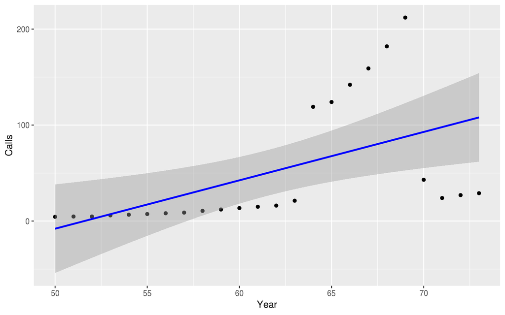

```r
ggplot(df, aes(x=df$year, y=df$calls)) + geom_point() +
  stat_smooth(method="lm", col="blue") + xlab("Year") + ylab("Calls")
```

### Medidas de diagnóstico

Ordenadas en forma decreciente por leverage.

```r
X = model.matrix(reg1)
P = X %*% solve(t(X) %*% X) %*% t(X)
leverages = diag(P)

df_diagnosis = data.frame(leverages=leverages,
                          stud_res=MASS::studres(reg1),
                          residuals=rstandard(reg1),
                          cook_d=cooks.distance(reg1))
kable(df_diagnosis[order(df_diagnosis$leverages, decreasing=T)[1:5], ])
```

|  | leverages | stud_res | residuals | cook_d |
| --- | --- | --- | --- | --- |
| 1 | 0.1566667 | 0.2346702 | 0.2398783 | 0.0053448 |
| 24 | 0.1566667 | -1.5806936 | -1.5294600 | 0.2172819 |
| 2 | 0.1375362 | 0.1430984 | 0.1463946 | 0.0017088 |
| 23 | 0.1375362 | -1.4943484 | -1.4541521 | 0.1686032 |
| 3 | 0.1201449 | 0.0482136 | 0.0493455 | 0.0001662 |

### Residuos estudentizados vs. leverage

La escala de colores está asociada a la distancia de cook. La etiqueta numérica es el índice del dato en el conjunto de datos original.

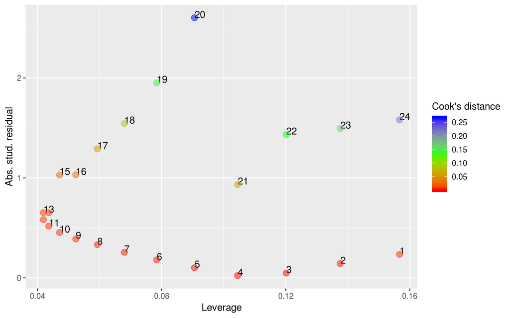

```r
# Residuals and cook distance
ggplot(data=df) +
  scale_colour_gradientn(colours=rainbow(3)) +
  geom_text(aes(label=1:nrow(df_diagnosis)), hjust=0, vjust=0, color="black", show.legend = F, check_overlap = T) +
  aes(x=df_diagnosis$leverages, y=abs(df_diagnosis$stud_res), color=df_diagnosis$cook_d) +
  geom_point(alpha=0.5, size=3) +
  labs(color="Cook's distance", x="Leverage", y="Abs. stud. residual")
```

### Boxplot de residuos estandarizados

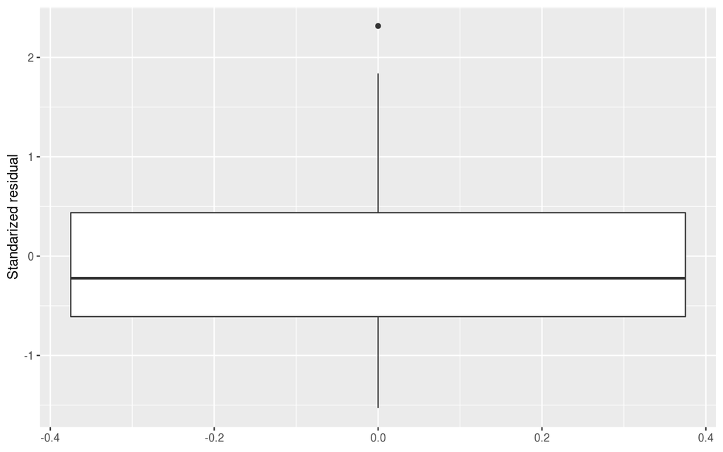

```r
ggplot(df, aes(y=rstandard(reg1))) +  geom_boxplot() +  ylab("Standarized residual")
```

### QQplot de residuos estandarizados

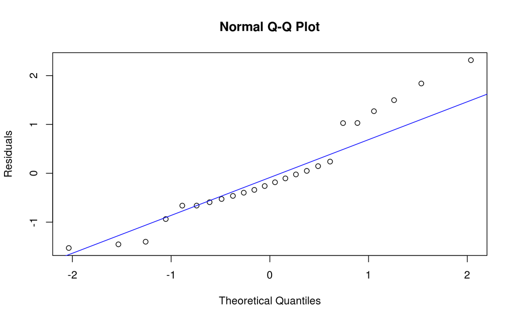

```r
qqnorm(rstandard(reg1), ylab="Residuals")
qqline(rstandard(reg1), col="blue")
```

# Item b

- Realice un scatterplot de year vs. calls en el que se grafique además la recta obtenida por mínimos cuadrados.
- ¿Qué le parece el ajuste obtenido? ¿Le parece que lo que se observa en el gráfico es bien reflejado por las medidas calculadas en item a?
- Si la respuesta es negativa, ¿cuál puede ser el motivo?
1. El ajuste obtenido no es bueno, evidentemente el modelo lineal planteado no es adecuado para este conjunto de datos. Se ve una estructura en la distribución que no es producto del azar. La hipótesis de errores normales claramente no se cumple en este modelo.
2. El gráfico de residuos estudentizados vs. leverage da cuenta de este fenómeno. Se pierde información sobre la estructura, pero se puede detectar la existencia de la misma.
3. El boxplot muestra que los residuos estandarizados no tienen una distribución empírica simétrica, aquí se puede observar un corrimiento hacia los valores positivos entre los residuos.
4. En el qqplot se nota el efecto descripto en los dos puntos anteriores.

# Item c

- Para el mismo modelo, ajuste los datos mediante un método robusto.
- Agregue al grádico de Item b la recta obtenida. ¿Nota diferencias?

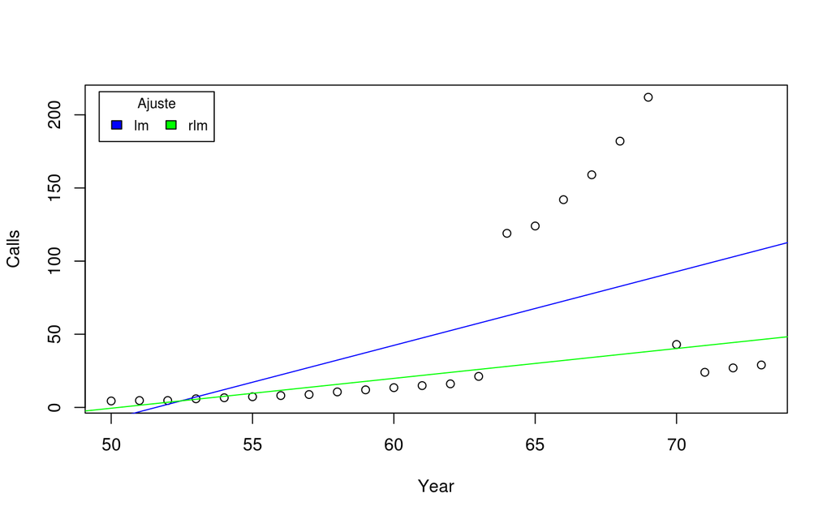

```r
# Ajuste robusto
reg2 = rlm(df$calls ~ df$year,  maxit=100)

plot(df$year, df$calls, xlab="Year", ylab="Calls")
abline(reg1, col="blue")
abline(reg2, col="green")
legend("topleft", inset=.02, title="Ajuste", c("lm","rlm"), fill=c("blue", "green"), horiz=TRUE, cex=0.8)
```

# Preguntas

1. ¿Qué es un Dfit?
2. Creo que en Item a no hace falta otro gráfico.
3. Cómo calcula los residuos estandarizados R ?

Mariano Barraco marianobarraco@gmail.com

2019-07-01